# Problemas de clasificación: Datos desbalanceados

Big Data and Machine Learning for Applied Economics - Econ 4676

Eduard-Martínez y Lucas Antonio II

Universidad de los Andes

# Introducción

Cuando nos enfrentamos a un **problema de clasificación** y la distribución de nuestra variable de interés no es homogenea entre las clases decimos que nos enfrentamos a una muestra desbalanceada. La clase que tiene mayor proporción de observaciones se conoce como clase mayoritaria y las demás categorías se conocen como clases minoritarías.

Según qué tan desbalanceada sea su base se puede clasificar el problema en diferentes categorías. Una buena regla del pulgar se encuentra en la siguiente tabla:

| **Grado de imbalance** | **Proporción de la clase minoritaria** |
| --- | --- |
| Leve | 20-40% de las observaciones |
| Moderado | 1-20% de las observaciones |
| Extremo | <1% de las observaciones |

La mayoría de problemas de clasificación son desbalanceados, algunos ejemplos son: detección de transacciones fraudulentas, detección de tumores en radiografías, [clasificación de éxitos músicales (wink wink)](https://repositorio.uniandes.edu.co/handle/1992/58861), entre muchos otros.

¿Por qué le damos un tratamiento especial a este tipo de problemas? En general, cuando se tienen pocas observaciones de una categoría los modelos tienden a tener problemas para aprender sobre las características que hacen que las observaciones pertenezcan a ella. Más aún, los modelos que se estiman utilizando descenso de gradiente en donde se utiliza una función de pérdida, se puede mostrar que una forma fácil de minimizar la pérdida es clasificando todas las observaciones en la categoría mayoritaria.

Analicemos una encuesta realizada por la empreza de condones Today para estudiar la infelidad en 1969 para dimensionar de donde viene nuestro problema estadístico.

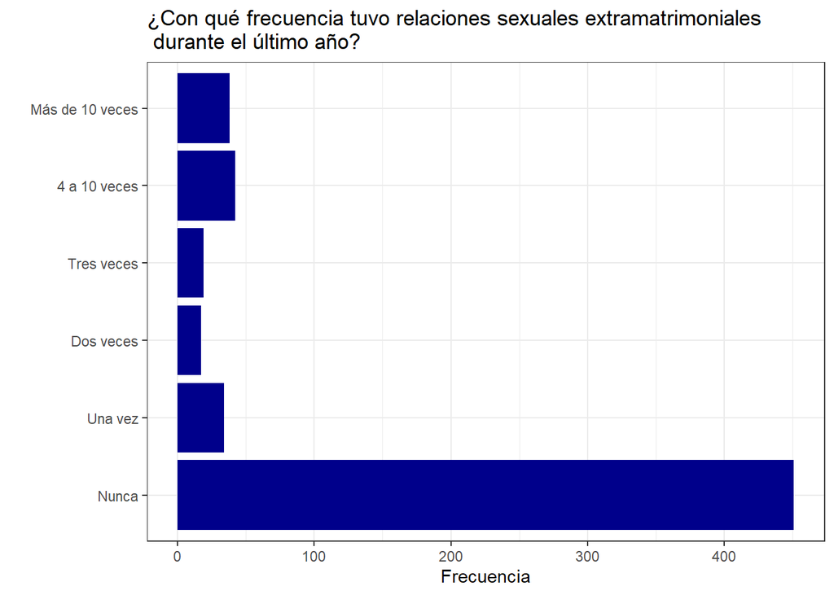

```r
# Cargamos la librería AER donde está alojada la data
library(pacman)
p_load(AER, tidyverse, caret, MLmetrics, tidymodels, themis)

# Importamos los datos
data("Affairs")

# Codificamos la variable de affairs según el diccionario
diccionario_affairs = c("Nunca", "Una vez", "Dos veces",
                        "Tres veces", "4 a 10 veces",
                        "Más de 10 veces")
Affairs$affairs <- factor(Affairs$affairs,
       levels = c(0, 1, 2, 3, 7, 12),
       labels = diccionario_affairs)

ggplot(Affairs, aes(x = affairs)) +
  geom_bar(fill = "darkblue") +
  theme_bw() +
  labs(title = "¿Con qué frecuencia tuvo relaciones sexuales extramatrimoniales \n durante el último año?",
       x = "",
       y = "Frecuencia") +
  coord_flip()
```

```r
# Creamos variable infiel
Affairs$infiel <- Affairs$affairs != "Nunca"

prop.table(table(Affairs$infiel))
```

```
##
##    FALSE     TRUE
## 0.750416 0.249584
```

Solo el 25% de los encuestados dice haber sido infiel el último año. Si queremos crear un modelo Logit para predecir la probabilidad de que alguien sea infiel nos enfrentaríamos a la siguiente función de log-verosimilitud:

$$\log(L(\theta)) = \sum_{i=1}^N
y_i*\log(\hat{y_i}) + (1-y_i)*\log(1-\hat{y_i})$$

En donde nuestra predicción $\hat{y_i}$ es el resultado de la función sigmoidea $\hat{y_i} = z(x) = \frac{1}{1+exp(-x)}$ en la cual $x$ podría ser de la forma: $\beta_0+\beta_1x_1+\cdots+\beta_kx_k$.

A continuación analicemos cómo evoluciona la función de log-verosimilitud para diferentes predicciones cuando el real valor a predecir es 1.

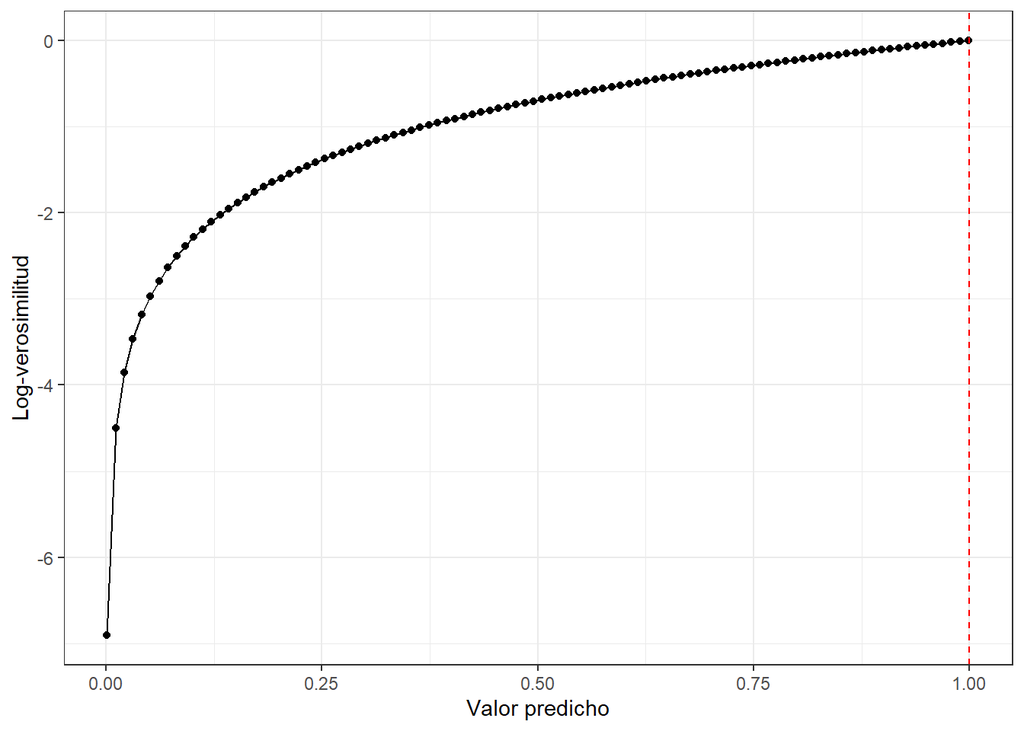

```r
LogLikelihood <- function (y_pred, y_true) {
  # Número cercano a cercano para evitar división por cero
  eps <- 1e-15
  # Si la probabilidad predicha es 0, agregale eps
  # Si la probabilidad predicha es 1, restele eps
  y_pred <- pmax(pmin(y_pred, 1 - eps), eps)
  # Pasamos de booleano a numerico
  y_true <- y_true + 0
  LogLoss <- sum(y_true * log(y_pred) + (1 - y_true) * log(1 - y_pred))
  return(LogLoss)
}

y_hat <- seq(0.001, 0.999, length.out = 100)

l <- c()
for (i in 1:100) {
  li <- LogLikelihood(y_pred = y_hat[i], y_true = 1)
  l <- c(l, li)
}

plot_f <- data.frame(y_hat = y_hat, log_likelihood = l)
ggplot(plot_f, aes(x = y_hat, y = log_likelihood)) +
  geom_point() +
  geom_line() +
  geom_vline(xintercept = 1, linetype = "dashed", color = "red") +
  theme_bw() +
  labs(x = "Valor predicho", y = "Log-verosimilitud")
```

En este caso deseamos maximizar la log-verosimilitud, sin embargo, este problema no tiene solución cerrada por ende debe ser estimada por métodos numéricos. A modo de ilustración, analicemos los escenarios en donde suponemos que el 100% de las personas son fieles ($\hat{y}=0$) versus un escenario donde el 75% lo son.

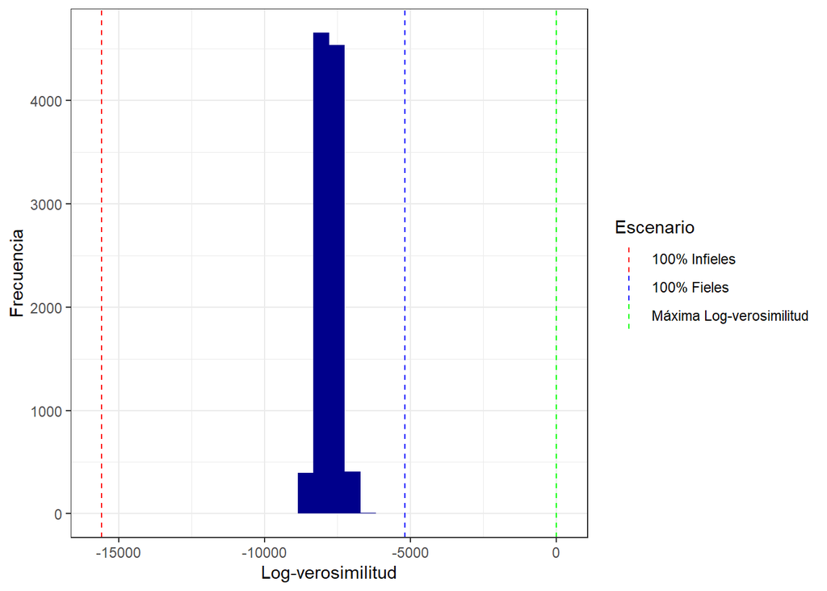

```r
# Log-verosimilitud cuando se dice que todas las personas son fieles
n <- nrow(Affairs)
y_hat_fieles <- rep(0, n)
l_fieles <- LogLikelihood(y_pred = y_hat_fieles, y_true = Affairs$infiel)

# Log-verosimilitud cuando todos son infieles
y_hat_infieles <- rep(1, n)
l_infieles <- LogLikelihood(y_pred = y_hat_infieles, y_true = Affairs$infiel)

# Log-verosimilitud cuando el 75% de las personas es fiel seleccionado al azar
y_hat_fieles75 <- c(rep(0, round(n*0.75, 0)), rep(1, round(n*0.25, 0)))
# Corremos 10000 simulaciones
set.seed(666)
l_fieles75 <- c()
for (i in 1:10000) {
  y_hat_fieles75_i <- sample(y_hat_fieles75, n)
  l_fieles75_i <- LogLikelihood(y_pred = y_hat_fieles75_i,
                                y_true = Affairs$infiel)
  l_fieles75 <- c(l_fieles75, l_fieles75_i)
}

# Log-verosimilitud cuando el 100% de las predicciones es correcta
l_maximo <- LogLikelihood(y_pred = Affairs$infiel, y_true = Affairs$infiel)

ggplot() +
  geom_histogram(aes(x = l_fieles75), fill = "darkblue") + theme_bw() +
  geom_vline(aes(xintercept = l_fieles,
                 color = "100% Fieles"), linetype = "dashed") +
  geom_vline(aes(xintercept = l_infieles,
                 color = "100% Infieles"), linetype = "dashed") +
  geom_vline(aes(xintercept = l_maximo,
                 color = "Máxima Log-verosimilitud"),
             linetype = "dashed") +
  labs(x = "Log-verosimilitud", y = "Frecuencia") +
  scale_color_manual(name = "Escenario",
                     values = c("100% Infieles" = "red",
                                "100% Fieles" = "blue",
                                "Máxima Log-verosimilitud" = "green"))
```

En el gráfico anterior observamos en azul oscuro la distribución de la log-verosimilitud luego de simular 10 mil escenarios diferentes en donde se realizan predicciones con la distribución correcta de las clases(75/25). Sin embargo, note que todos los escenarios simulados tienen un peor desempeño que el escenario donde siempre se supone que todas las personas son fieles.

Este ejemplo es ilustrativo en el sentido de que muestra como nuestros algoritmos tienden a estar sesgados a favorecer siempre la categoría mayoritaria. Por tal motivo, se deben tener algunas consideraciones relevantes a la hora de trabajar con datos desbalanceados.

# Ejercicio práctico

Comenzaremos tratando de predecir si las personas dentro de nuestra muestra son fieles o no. Nuestro baseline siempre debe ser trabajar con nuestra muestra tal cual está. Si los resultados son buenos, coronamos! En caso de ver que la cosa es complicada, vamos a probar diferentes técnicas.

Comencemos analizando las variables que tenemos en la base:

```r
glimpse(Affairs)
```

```
## Rows: 601
## Columns: 10
## $ affairs       <fct> Nunca, Nunca, Nunca, Nunca, Nunca, Nunca, Nunca, Nunca, …
## $ gender        <fct> male, female, female, male, male, female, female, male, …
## $ age           <dbl> 37, 27, 32, 57, 22, 32, 22, 57, 32, 22, 37, 27, 47, 22, …
## $ yearsmarried  <dbl> 10.00, 4.00, 15.00, 15.00, 0.75, 1.50, 0.75, 15.00, 15.0…
## $ children      <fct> no, no, yes, yes, no, no, no, yes, yes, no, yes, yes, ye…
## $ religiousness <int> 3, 4, 1, 5, 2, 2, 2, 2, 4, 4, 2, 4, 5, 2, 4, 1, 2, 3, 2,…
## $ education     <dbl> 18, 14, 12, 18, 17, 17, 12, 14, 16, 14, 20, 18, 17, 17, …
## $ occupation    <int> 7, 6, 1, 6, 6, 5, 1, 4, 1, 4, 7, 6, 6, 5, 5, 5, 4, 5, 5,…
## $ rating        <int> 4, 4, 4, 5, 3, 5, 3, 4, 2, 5, 2, 4, 4, 4, 4, 5, 3, 4, 5,…
## $ infiel        <lgl> FALSE, FALSE, FALSE, FALSE, FALSE, FALSE, FALSE, FALSE, …
```

El diccionario de la base es el siguiente:

- **affairs**: How often engaged in extramarital sexual intercourse during the past year? 0 = none, 1 = once, 2 = twice, 3 = 3 times, 7 = 4–10 times, 12 = > 10 times.
- **gender**: factor indicating gender.
- **age**: age in years: 17.5 = under 20, 22 = 20–24, 27 = 25–29, 32 = 30–34, 37 = 35–39, 42 = 40–44, 47 = 45–49, 52 = 50–54, 57 = 55 or over.
- **yearsmarried**: number of years married: 0.125 = 3 months or less, 0.417 = 4–6 months, 0.75 = 6 months–1 year, 1.5 = 1–2 years, 4 = 3–5 years, 7 = 6–8 years, 10 = 9–11 years, 15 = 12 or more years.
- **children**: Are there children in the marriage?
- **religiousness**: 1 = anti, 2 = not at all, 3 = slightly, 4 = somewhat, 5 = very.
- **education**: numeric variable coding level of education: 9 = grade school, 12 = high school graduate, 14 = some college, 16 = college graduate, 17 = some graduate work, 18 = master’s degree, 20 = Ph.D., M.D., or other advanced degree.
- **occupation**: numeric variable coding occupation according to Hollingshead classification (reverse numbering).
- **rating**: numeric variable coding self rating of marriage: 1 = very unhappy, 2 = somewhat unhappy, 3 = average, 4 = happier than average, 5 = very happy.

En este caso, decidir la clase/el tipo de cada una de las variables no es trivial, por lo pronto escogeremos lo siguiente:

```r
Affairs$occupation <- factor(Affairs$occupation)
Affairs$education <- factor(Affairs$education)
```

Ahora vamos a dummyficar la base, partir en entrenamiento y validación y estandarizar.

```r
# Dummyficamos ANTES de partir la base en train/test
# Creamos las variables edad y años de casados al cuadrado
df <- model.matrix(~ . + I(age^2) + I(yearsmarried^2) - affairs - 1, Affairs)

# Dividimos train/test (70/30)
smp_size <- floor(0.7*n)
set.seed(666)
train_ind <- sample(1:n, size = smp_size)

train <- df[train_ind, ]
test <- df[-train_ind, ]

# Estandarizamos DESPUÉS de partir la base en train/test
variables_numericas <- c("age", "yearsmarried", "religiousness",
                         "rating", "I(age^2)", "I(yearsmarried^2)")
escalador <- preProcess(train[, variables_numericas])
train_s <- train
test_s <- test
train_s[, variables_numericas] <- predict(escalador, train[, variables_numericas])
test_s[, variables_numericas] <- predict(escalador, test[, variables_numericas])
```

Ahora ajustemos una regresión lineal y veamos que nos sale

```r
train_s <- data.frame(train_s)
test_s <- data.frame(test_s)
train <- data.frame(train)
test <- data.frame(test)

train_s$infielTRUE <- as.numeric(train_s$infielTRUE)
modelo1 <- lm(formula = infielTRUE ~ ., data = train_s)
probs_insample1 <- predict(modelo1, train_s)
probs_insample1[probs_insample1 < 0] <- 0
probs_insample1[probs_insample1 > 1] <- 1
probs_outsample1 <- predict(modelo1, test_s)
probs_outsample1[probs_outsample1 < 0] <- 0
probs_outsample1[probs_outsample1 > 1] <- 1

# Convertimos la probabilidad en una predicción
y_hat_insample1 <- as.numeric(probs_insample1 > 0.5)
y_hat_outsample1 <- as.numeric(probs_outsample1 > 0.5)

acc_insample1 <- Accuracy(y_pred = y_hat_insample1, y_true = train$infielTRUE)
acc_outsample1 <- Accuracy(y_pred = y_hat_outsample1, y_true = test$infielTRUE)

pre_insample1 <- Precision(y_pred = y_hat_insample1, y_true = train$infielTRUE, positive = 1)
pre_outsample1 <- Precision(y_pred = y_hat_outsample1, y_true = test$infielTRUE, positive = 1)

rec_insample1 <- Recall(y_pred = y_hat_insample1, y_true = train$infielTRUE, positive = 1)
rec_outsample1 <- Recall(y_pred = y_hat_outsample1, y_true = test$infielTRUE, positive = 1)

f1_insample1 <- F1_Score(y_pred = y_hat_insample1, y_true = train$infielTRUE, positive = 1)
f1_outsample1 <- F1_Score(y_pred = y_hat_outsample1, y_true = test$infielTRUE, positive = 1)

metricas_insample1 <- data.frame(Modelo = "Regresión lineal",
           "Muestreo" = NA,
           "Evaluación" = "Dentro de muestra",
           "Accuracy" = acc_insample1,
           "Precision" = pre_insample1,
           "Recall" = rec_insample1,
           "F1" = f1_insample1)

metricas_outsample1 <- data.frame(Modelo = "Regresión lineal",
           "Muestreo" = NA,
           "Evaluación" = "Fuera de muestra",
           "Accuracy" = acc_outsample1,
           "Precision" = pre_outsample1,
           "Recall" = rec_outsample1,
           "F1" = f1_outsample1)

metricas1 <- bind_rows(metricas_insample1, metricas_outsample1)
metricas1 %>%
  kbl(digits = 2)  %>%
  kable_styling(full_width = T)
```

| Modelo | Muestreo | Evaluación | Accuracy | Precision | Recall | F1 |
| --- | --- | --- | --- | --- | --- | --- |
| Regresión lineal | NA | Dentro de muestra | 0.79 | 0.71 | 0.20 | 0.31 |
| Regresión lineal | NA | Fuera de muestra | 0.73 | 0.50 | 0.12 | 0.20 |

Note el contraste tan grande entre la métrica Accuracy y las demás! Por la forma en la que está definida, la métrica de Accuracy le asigna el mismo peso a las observaciones de infieles y fieles, sin embargo, en este caso queremos enfoncarnos en predecir mejor a los infieles. **El Accuracy NO es una buena métrica para muestras desbalanceadas**. Dependiendo de si somos más sensibles a los falsos positivos o a los falsos negativos debemos escoger la métrica de Precision o Recall. Si somos igual de sensibles entre ambas se recomienda usar el F1 Score. No obstante, podemos usar el F-Beta Score para considerar tanto Precision como Recall pero en este caso le asigna los pesos de Recall = Beta*Precision. Por ende, si Beta es 2 significa que el Recall es dos veces más importante que Precision. Cuando Beta es 0.5, Precision es 2 veces más importante que el Recall, etc.

# Soluciones posibles

Usualmente cuando el desbalance de nuestra muestra es un problema podemos tratar de seguir uno, alguno o todos de los siguientes caminos:

1. **Remuestreo**: Acá podemos o aumentar el número de observaciones de nuestra(s) clase(s) minoritaría(s) haciendo uso de técnicas de *oversampling* o eliminando observaciones de la clase mayoritaria a partir de técnicas de *undersampling*. El objetivo de esta técnica es garantizar que la distribución entre marcas sea cercana a la uniformidad. **OJO:**
- En caso de que realice alguna técnica de muestreo, nunca realice una evaluación del modelo sobre los datos **después** de este proceso. La evaluación de los modelos debe ser sobre los datos sin balancear.
- Si implementa la validación cruzada, recuerde sobremuestrear o submuestrear sus datos de entrenamiento durante la validación cruzada, **no antes**.
2. **Optimizar el umbral de decisión**: Por default siempre se escoge como punto de corte 0.5 a la hora de clasificar nuestras predicciones como 1 o 0. No obstante, se puede cambiar el umbral de probabilidad buscando maximizar alguna métrica de desempeño.
3. **Cambiar los pesos de la función de pérdida**: Cuando estimamos nuestros modelos por Máxima Verosimilitud y/o usando Gradiente Descendiente podemos asignarle diferentes pesos a las observaciones de modo que el modelo se esfuerce más por predecir correctamente la clase minoritaria. Por ejemplo tenemos la función de Log-Verosimilitud ponderada por $\omega_i$:
   $$\log(L(\theta))=\sum_{i=1}^N
   \omega_i[y_i*\log(\hat{y_i}) +
   (1-y_i)*\log(1-\hat{y_i})]$$

## Remuestreo - Oversampling

```r
# Implementamos oversampling
train_s$infielTRUE <- factor(train_s$infielTRUE)
train_s2 <- recipe(infielTRUE ~ ., data = train_s) %>%
  themis::step_smote(infielTRUE, over_ratio = 1) %>%
  prep() %>%
  bake(new_data = NULL)

prop.table(table(train_s$infielTRUE))
```

```
##
##         0         1
## 0.7571429 0.2428571
```

```r
nrow(train_s)
```

```
## [1] 420
```

```r
prop.table(table(train_s2$infielTRUE))
```

```
##
##   0   1
## 0.5 0.5
```

```r
nrow(train_s2)
```

```
## [1] 636
```

```r
train_s2$infielTRUE <- as.numeric(train_s2$infielTRUE) - 1
modelo2 <- lm(formula = "infielTRUE ~ .", data = train_s2)
probs_insample2 <- predict(modelo2, train_s2)
probs_insample2[probs_insample2 < 0] <- 0
probs_insample2[probs_insample2 > 1] <- 1
probs_outsample2 <- predict(modelo2, test_s)
probs_outsample2[probs_outsample2 < 0] <- 0
probs_outsample2[probs_outsample2 > 1] <- 1

# Convertimos la probabilidad en una predicción
y_hat_insample2 <- as.numeric(probs_insample2 > 0.5)
y_hat_outsample2 <- as.numeric(probs_outsample2 > 0.5)

acc_insample2 <- Accuracy(y_pred = y_hat_insample2, y_true = train_s2$infielTRUE)
acc_outsample2 <- Accuracy(y_pred = y_hat_outsample2, y_true = test$infielTRUE)

pre_insample2 <- Precision(y_pred = y_hat_insample2, y_true = train_s2$infielTRUE, positive = 1)
pre_outsample2 <- Precision(y_pred = y_hat_outsample2, y_true = test$infielTRUE, positive = 1)

rec_insample2 <- Recall(y_pred = y_hat_insample2, y_true = train_s2$infielTRUE, positive = 1)
rec_outsample2 <- Recall(y_pred = y_hat_outsample2, y_true = test$infielTRUE, positive = 1)

f1_insample2 <- F1_Score(y_pred = y_hat_insample2, y_true = train_s2$infielTRUE, positive = 1)
f1_outsample2 <- F1_Score(y_pred = y_hat_outsample2, y_true = test$infielTRUE, positive = 1)

metricas_insample2 <- data.frame(Modelo = "Regresión lineal",
           "Muestreo" = "SMOTE - Oversampling",
           "Evaluación" = "Dentro de muestra",
           "Accuracy" = acc_insample2,
           "Precision" = pre_insample2,
           "Recall" = rec_insample2,
           "F1" = f1_insample2)

metricas_outsample2 <- data.frame(Modelo = "Regresión lineal",
           "Muestreo" = "SMOTE - Oversampling",
           "Evaluación" = "Fuera de muestra",
           "Accuracy" = acc_outsample2,
           "Precision" = pre_outsample2,
           "Recall" = rec_outsample2,
           "F1" = f1_outsample2)

metricas2 <- bind_rows(metricas_insample2, metricas_outsample2)
metricas <- bind_rows(metricas1, metricas2)

metricas %>%
  kbl(digits = 2)  %>%
  kable_styling(full_width = T)
```

| Modelo | Muestreo | Evaluación | Accuracy | Precision | Recall | F1 |
| --- | --- | --- | --- | --- | --- | --- |
| Regresión lineal | NA | Dentro de muestra | 0.79 | 0.71 | 0.20 | 0.31 |
| Regresión lineal | NA | Fuera de muestra | 0.73 | 0.50 | 0.12 | 0.20 |
| Regresión lineal | SMOTE - Oversampling | Dentro de muestra | 0.69 | 0.69 | 0.70 | 0.70 |
| Regresión lineal | SMOTE - Oversampling | Fuera de muestra | 0.61 | 0.35 | 0.56 | 0.43 |

## Remuestreo - Undersampling

```r
# Implementamos oversampling
train_s$infielTRUE <- factor(train_s$infielTRUE)
train_s3 <- recipe(infielTRUE ~ ., data = train_s) %>%
  themis::step_downsample(infielTRUE) %>%
  prep() %>%
  bake(new_data = NULL)

prop.table(table(train_s$infielTRUE))
```

```
##
##         0         1
## 0.7571429 0.2428571
```

```r
nrow(train_s)
```

```
## [1] 420
```

```r
prop.table(table(train_s3$infielTRUE))
```

```
##
##   0   1
## 0.5 0.5
```

```r
nrow(train_s3)
```

```
## [1] 204
```

```r
train_s3$infielTRUE <- as.numeric(train_s3$infielTRUE) - 1
modelo3 <- lm(formula = "infielTRUE ~ .", data = train_s3)
probs_insample3 <- predict(modelo3, train_s3)
probs_insample3[probs_insample3 < 0] <- 0
probs_insample3[probs_insample3 > 1] <- 1
probs_outsample3 <- predict(modelo3, test_s)
probs_outsample3[probs_outsample3 < 0] <- 0
probs_outsample3[probs_outsample3 > 1] <- 1

# Convertimos la probabilidad en una predicción
y_hat_insample3 <- as.numeric(probs_insample3 > 0.5)
y_hat_outsample3 <- as.numeric(probs_outsample3 > 0.5)

acc_insample3 <- Accuracy(y_pred = y_hat_insample3, y_true = train_s3$infielTRUE)
acc_outsample3 <- Accuracy(y_pred = y_hat_outsample3, y_true = test$infielTRUE)

pre_insample3 <- Precision(y_pred = y_hat_insample3, y_true = train_s3$infielTRUE, positive = 1)
pre_outsample3 <- Precision(y_pred = y_hat_outsample3, y_true = test$infielTRUE, positive = 1)

rec_insample3 <- Recall(y_pred = y_hat_insample3, y_true = train_s3$infielTRUE, positive = 1)
rec_outsample3 <- Recall(y_pred = y_hat_outsample3, y_true = test$infielTRUE, positive = 1)

f1_insample3 <- F1_Score(y_pred = y_hat_insample3, y_true = train_s3$infielTRUE, positive = 1)
f1_outsample3 <- F1_Score(y_pred = y_hat_outsample3, y_true = test$infielTRUE, positive = 1)

metricas_insample3 <- data.frame(Modelo = "Regresión lineal",
           "Muestreo" = "Undersampling",
           "Evaluación" = "Dentro de muestra",
           "Accuracy" = acc_insample3,
           "Precision" = pre_insample3,
           "Recall" = rec_insample3,
           "F1" = f1_insample3)

metricas_outsample3 <- data.frame(Modelo = "Regresión lineal",
           "Muestreo" = "Undersampling",
           "Evaluación" = "Fuera de muestra",
           "Accuracy" = acc_outsample3,
           "Precision" = pre_outsample3,
           "Recall" = rec_outsample3,
           "F1" = f1_outsample3)

metricas3 <- bind_rows(metricas_insample3, metricas_outsample3)
metricas <- bind_rows(metricas, metricas3)

metricas %>%
  kbl(digits = 2)  %>%
  kable_styling(full_width = T)
```

| Modelo | Muestreo | Evaluación | Accuracy | Precision | Recall | F1 |
| --- | --- | --- | --- | --- | --- | --- |
| Regresión lineal | NA | Dentro de muestra | 0.79 | 0.71 | 0.20 | 0.31 |
| Regresión lineal | NA | Fuera de muestra | 0.73 | 0.50 | 0.12 | 0.20 |
| Regresión lineal | SMOTE - Oversampling | Dentro de muestra | 0.69 | 0.69 | 0.70 | 0.70 |
| Regresión lineal | SMOTE - Oversampling | Fuera de muestra | 0.61 | 0.35 | 0.56 | 0.43 |
| Regresión lineal | Undersampling | Dentro de muestra | 0.64 | 0.65 | 0.62 | 0.63 |
| Regresión lineal | Undersampling | Fuera de muestra | 0.58 | 0.33 | 0.56 | 0.42 |

## Optimizar el umbral de decisión

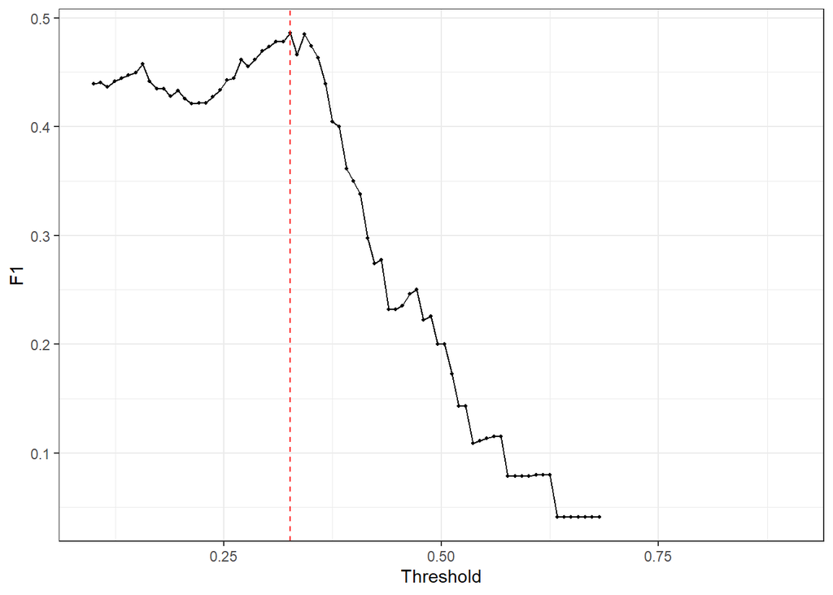

```r
# Esto no se debería hacer sobre la base de testeo pero se hace solo a modo ilustrativo
thresholds <- seq(0.1, 0.9, length.out = 100)
opt_t <- data.frame()
for (t in thresholds) {
  y_pred_t <- as.numeric(probs_outsample1 > t)
  f1_t <- F1_Score(y_true = test$infielTRUE, y_pred = y_pred_t,
                   positive = 1)
  fila <- data.frame(t = t, F1 = f1_t)
  opt_t <- bind_rows(opt_t, fila)
}

mejor_t <-  opt_t$t[which(opt_t$F1 == max(opt_t$F1, na.rm = T))]

ggplot(opt_t, aes(x = t, y = F1)) +
  geom_point(size = 0.7) +
  geom_line() +
  theme_bw() +
  geom_vline(xintercept = mejor_t, linetype = "dashed",
             color = "red") +
  labs(x = "Threshold")
```

```r
# Convertimos la probabilidad en una predicción
y_hat_insample4 <- as.numeric(probs_insample1 > mejor_t)
y_hat_outsample4 <- as.numeric(probs_outsample1 > mejor_t)

acc_insample4 <- Accuracy(y_pred = y_hat_insample4, y_true = train_s$infielTRUE)
acc_outsample4 <- Accuracy(y_pred = y_hat_outsample4, y_true = test$infielTRUE)

pre_insample4 <- Precision(y_pred = y_hat_insample4, y_true = train_s$infielTRUE, positive = 1)
pre_outsample4 <- Precision(y_pred = y_hat_outsample4, y_true = test$infielTRUE, positive = 1)

rec_insample4 <- Recall(y_pred = y_hat_insample4, y_true = train_s$infielTRUE, positive = 1)
rec_outsample4 <- Recall(y_pred = y_hat_outsample4, y_true = test$infielTRUE, positive = 1)

f1_insample4 <- F1_Score(y_pred = y_hat_insample4, y_true = train_s$infielTRUE, positive = 1)
f1_outsample4 <- F1_Score(y_pred = y_hat_outsample4, y_true = test$infielTRUE, positive = 1)

metricas_insample4 <- data.frame(Modelo = "Regresión lineal - Threshold óptimo",
           "Muestreo" = NA,
           "Evaluación" = "Dentro de muestra",
           "Accuracy" = acc_insample4,
           "Precision" = pre_insample4,
           "Recall" = rec_insample4,
           "F1" = f1_insample4)

metricas_outsample4 <- data.frame(Modelo = "Regresión lineal - Threshold óptimo",
           "Muestreo" = NA,
           "Evaluación" = "Fuera de muestra",
           "Accuracy" = acc_outsample4,
           "Precision" = pre_outsample4,
           "Recall" = rec_outsample4,
           "F1" = f1_outsample4)

metricas4 <- bind_rows(metricas_insample4, metricas_outsample4)
metricas <- bind_rows(metricas, metricas4)

metricas %>%
  kbl(digits = 2)  %>%
  kable_styling(full_width = T)
```

| Modelo | Muestreo | Evaluación | Accuracy | Precision | Recall | F1 |
| --- | --- | --- | --- | --- | --- | --- |
| Regresión lineal | NA | Dentro de muestra | 0.79 | 0.71 | 0.20 | 0.31 |
| Regresión lineal | NA | Fuera de muestra | 0.73 | 0.50 | 0.12 | 0.20 |
| Regresión lineal | SMOTE - Oversampling | Dentro de muestra | 0.69 | 0.69 | 0.70 | 0.70 |
| Regresión lineal | SMOTE - Oversampling | Fuera de muestra | 0.61 | 0.35 | 0.56 | 0.43 |
| Regresión lineal | Undersampling | Dentro de muestra | 0.64 | 0.65 | 0.62 | 0.63 |
| Regresión lineal | Undersampling | Fuera de muestra | 0.58 | 0.33 | 0.56 | 0.42 |
| Regresión lineal - Threshold óptimo | NA | Dentro de muestra | 0.74 | 0.47 | 0.58 | 0.52 |
| Regresión lineal - Threshold óptimo | NA | Fuera de muestra | 0.70 | 0.44 | 0.54 | 0.49 |